# report data analysis (first order difference)

Chiho Taniguchi

2023-04-13

# cz data

## First stage (cz)

Regress the difference between 2014 and 2010 in the number of general establishments (log_diff_10_14) on the percentage of tokutei establishments at the initial period(share_cz_2010). “log_diff_10_14” is the natural logarithm of the number of general establishments in 2014 minus the natural logarithm of the number of general establishments in 2010.

### log_diff_10_14

taking log difference (ln(X_2014) - ln(X_2010))

```
##    Min. 1st Qu.  Median    Mean 3rd Qu.    Max.
## -1.7918 -0.3185 -0.1529 -0.2003  0.0000  1.3863
```

|  | log_diff_10_14 |
| --- | --- |
| (Intercept) | −0.412*** |
|  | [−0.642, −0.182] |
| share_cz_2010 | 0.332+ |
|  | [−0.020, 0.685] |
| Num.Obs. | 198 |
| R2 | 0.017 |
| R2 Adj. | 0.012 |
| Log.Lik. | −73.586 |
| F | 3.465 |
| RMSE | 0.35 |

+ p < 0.1, * p < 0.05, ** p < 0.01, *** p < 0.001

### diff_14_10

```
##    Min. 1st Qu.  Median    Mean 3rd Qu.    Max.
## -644.00   -9.00   -3.00  -12.58    0.00   15.00
```

|  | diff_14_10 |
| --- | --- |
| (Intercept) | −0.016 |
|  | [−0.050, 0.017] |
| share_cz_2010 | 0.006 |
|  | [−0.045, 0.058] |
| Num.Obs. | 198 |
| R2 | 0.000 |
| R2 Adj. | −0.005 |
| Log.Lik. | 306.654 |
| F | 0.055 |
| RMSE | 0.05 |

+ p < 0.1, * p < 0.05, ** p < 0.01, *** p < 0.001

## First stage (weighted by the number of general establishments in 2010)

### log_diff_10_14

|  | log_diff_10_14(weighted) |
| --- | --- |
| (Intercept) | −0.138 |
|  | [−0.320, 0.044] |
| share_cz_2010 | −0.062 |
|  | [−0.350, 0.227] |
| Num.Obs. | 198 |
| R2 | 0.001 |
| R2 Adj. | −0.004 |
| Log.Lik. | −28.710 |
| F | 0.178 |
| RMSE | 0.36 |

+ p < 0.1, * p < 0.05, ** p < 0.01, *** p < 0.001

### diff_14_10

|  | diff_14_10(weighted) |
| --- | --- |
| (Intercept) | 0.059 |
|  | [−0.290, 0.409] |
| share_cz_2010 | −0.422 |
|  | [−0.976, 0.132] |
| Num.Obs. | 198 |
| R2 | 0.011 |
| R2 Adj. | 0.006 |
| Log.Lik. | −157.954 |
| F | 2.257 |
| RMSE | 0.21 |

+ p < 0.1, * p < 0.05, ** p < 0.01, *** p < 0.001

## Plot for first stage

“estab.” represents establishments. y represents “log(#general establishments in 2014) - log(#general establishments in 2010)”.

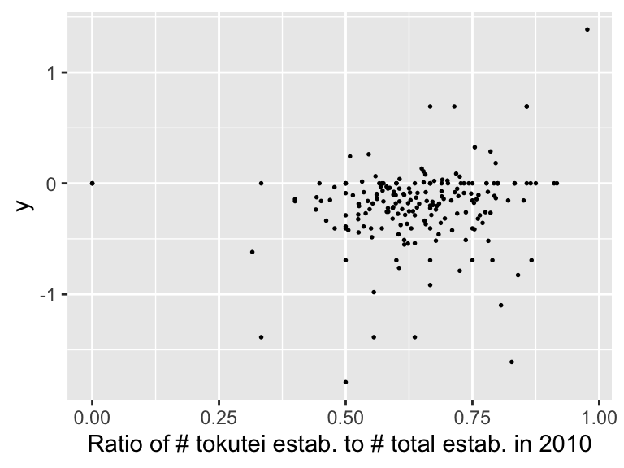

## binscatter plot for first stage

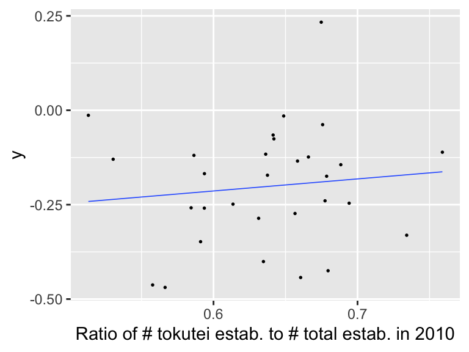

## Reduced form (cz)

Regress first order difference of the natural logarithm of the average wage and the average fee(log_diffwage_14_10 / flog_difffee_14_10) on the percentage of tokutei establishments at the initial period(share_cz_2010). The natural logarithm of the average wage and average fee are calculated by creating panel data by making the average of each cz level year by year. log_diffwage_14_10 / flog_difffee_14_10 is log(average wage / fee in 2014) - log(average wage / fee in 2010).

### wage (log_diffwage_14_10)

|  | log_diffwage_14_10 |
| --- | --- |
| (Intercept) | −0.075 |
|  | [−0.192, 0.043] |
| share_cz_2010 | 0.136 |
|  | [−0.044, 0.316] |
| Num.Obs. | 198 |
| R2 | 0.011 |
| R2 Adj. | 0.006 |
| Log.Lik. | 59.193 |
| F | 2.206 |
| RMSE | 0.18 |

+ p < 0.1, * p < 0.05, ** p < 0.01, *** p < 0.001

### wage (wage_growth_14_10)

|  | wage_growth_14_10 |
| --- | --- |
| (Intercept) | −0.045 |
|  | [−0.253, 0.163] |
| share_cz_2010 | 0.123 |
|  | [−0.195, 0.441] |
| Num.Obs. | 198 |
| R2 | 0.003 |
| R2 Adj. | −0.002 |
| Log.Lik. | −53.418 |
| F | 0.583 |
| RMSE | 0.32 |

+ p < 0.1, * p < 0.05, ** p < 0.01, *** p < 0.001

### wage(weighted / log_diffwage_14_10)

|  | log_diffwage_14_10(weighted) |
| --- | --- |
| (Intercept) | 0.052 |
|  | [−0.073, 0.177] |
| share_cz_2010 | −0.086 |
|  | [−0.285, 0.112] |
| Num.Obs. | 198 |
| R2 | 0.004 |
| R2 Adj. | −0.001 |
| Log.Lik. | 45.556 |
| F | 0.740 |
| RMSE | 0.18 |

+ p < 0.1, * p < 0.05, ** p < 0.01, *** p < 0.001

### wage(weighted / wage_growth_14_10)

|  | wage_growth_14_10(weighted) |
| --- | --- |
| (Intercept) | 0.081 |
|  | [−0.169, 0.331] |
| share_cz_2010 | −0.122 |
|  | [−0.519, 0.275] |
| Num.Obs. | 198 |
| R2 | 0.002 |
| R2 Adj. | −0.003 |
| Log.Lik. | −91.882 |
| F | 0.369 |
| RMSE | 0.32 |

+ p < 0.1, * p < 0.05, ** p < 0.01, *** p < 0.001

### Plot for reduced form (wage)

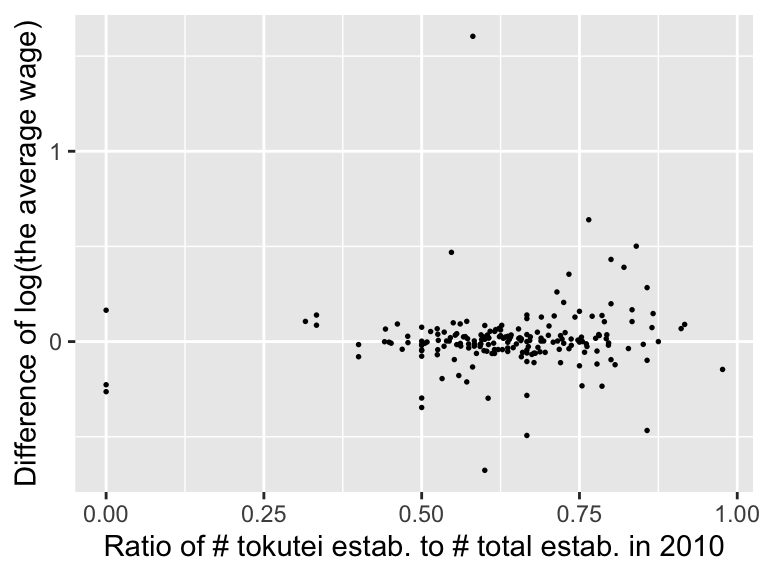

### binscatter plot for reduced form (wage)

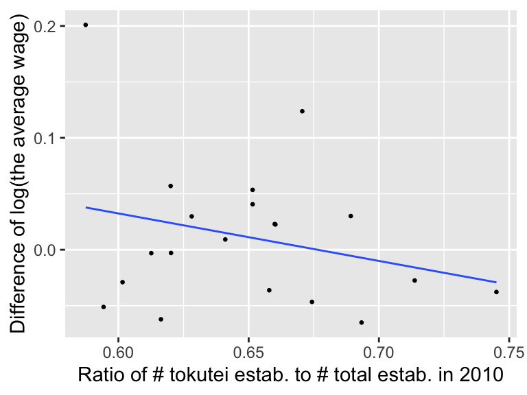

### fee (log_difffee_14_10)

|  | log_difffee_14_10 |
| --- | --- |
| (Intercept) | −0.157** |
|  | [−0.254, −0.059] |
| share_cz_2010 | 0.274*** |
|  | [0.125, 0.423] |
| Num.Obs. | 198 |
| R2 | 0.063 |
| R2 Adj. | 0.058 |
| Log.Lik. | 96.784 |
| F | 13.165 |
| RMSE | 0.15 |

+ p < 0.1, * p < 0.05, ** p < 0.01, *** p < 0.001

### fee (fee_growth_14_10)

|  | fee_growth_14_10 |
| --- | --- |
| (Intercept) | −0.172** |
|  | [−0.280, −0.064] |
| share_cz_2010 | 0.318*** |
|  | [0.152, 0.484] |
| Num.Obs. | 198 |
| R2 | 0.068 |
| R2 Adj. | 0.063 |
| Log.Lik. | 75.433 |
| F | 14.252 |
| RMSE | 0.17 |

+ p < 0.1, * p < 0.05, ** p < 0.01, *** p < 0.001

### fee(log_difffee_14_10 / weighted)

|  | log_difffee_14_10(weighted) |
| --- | --- |
| (Intercept) | 0.028 |
|  | [−0.049, 0.106] |
| share_cz_2010 | −0.030 |
|  | [−0.153, 0.094] |
| Num.Obs. | 198 |
| R2 | 0.001 |
| R2 Adj. | −0.004 |
| Log.Lik. | 139.014 |
| F | 0.225 |
| RMSE | 0.15 |

+ p < 0.1, * p < 0.05, ** p < 0.01, *** p < 0.001

### fee(fee_growth_14_10 / weighted)

|  | log_difffee_14_10(weighted) |
| --- | --- |
| (Intercept) | 0.020 |
|  | [−0.062, 0.103] |
| share_cz_2010 | −0.014 |
|  | [−0.144, 0.117] |
| Num.Obs. | 198 |
| R2 | 0.000 |
| R2 Adj. | −0.005 |
| Log.Lik. | 128.150 |
| F | 0.042 |
| RMSE | 0.17 |

+ p < 0.1, * p < 0.05, ** p < 0.01, *** p < 0.001

### Plot for reduced form (fee)

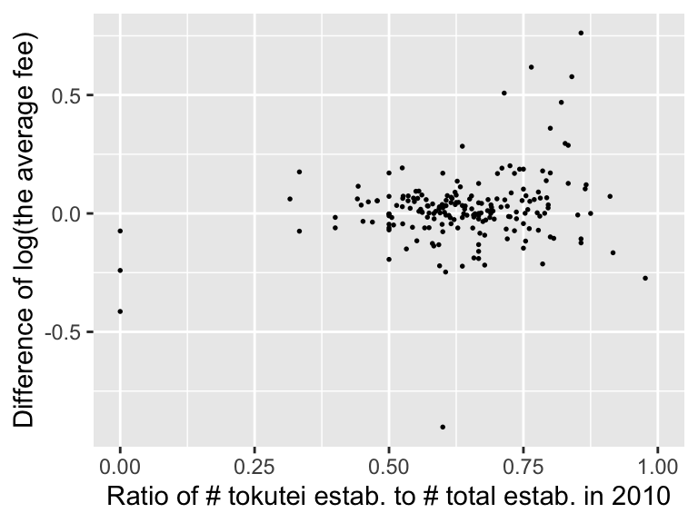

### binscatter plot for reduced form (fee)

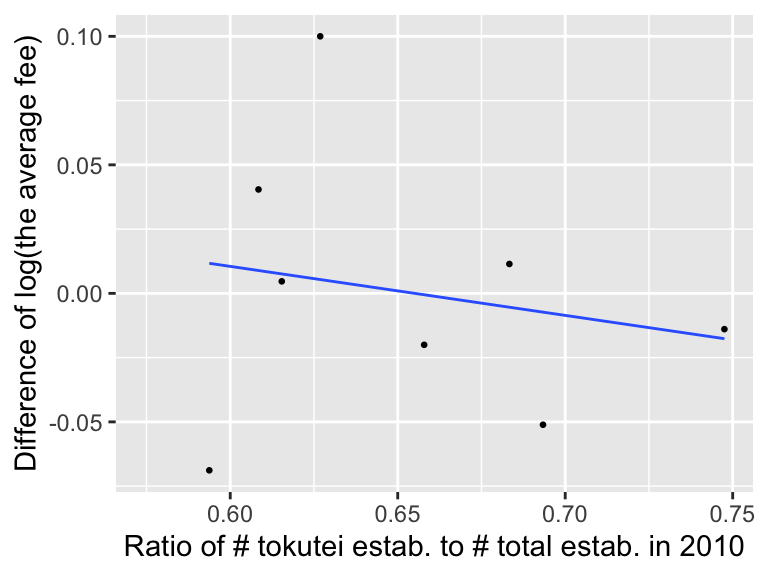

## Structural form (cz)

Regress the difference between the natural logarithm of average wages and average rates on the difference between 2014 and 2010 in the number of general establishments (log_diffwage/fee_14_10). We use the ratio of tokutei establishments at the initial periods as the instrument variable for the difference between the natural logarithm of average wages and average rates on the difference between 2014 and 2010 in the number of general establishments (log_diff_10_14).

### 2nd stage (wage / log_diffwage_14_10)

|  | log_diffwage_14_10 |
| --- | --- |
| (Intercept) | 0.093 |
|  | [−0.051, 0.237] |
| log_diff_10_14(fit) | 0.408 |
|  | [−0.292, 1.108] |
| Num.Obs. | 198 |
| R2 | −0.649 |
| R2 Adj. | −0.658 |
| RMSE | 0.23 |

+ p < 0.1, * p < 0.05, ** p < 0.01, *** p < 0.001

### 2nd stage (wage / wage_growth_14_10)

|  | log_diffwage_14_10 |
| --- | --- |
| (Intercept) | 0.287 |
|  | [−1.941, 2.515] |
| diff_14_10_1000(fit) | 20.131 |
|  | [−156.607, 196.869] |
| Num.Obs. | 198 |
| R2 | −10.512 |
| R2 Adj. | −10.571 |
| RMSE | 1.08 |

+ p < 0.1, * p < 0.05, ** p < 0.01, *** p < 0.001

### 2nd stage (wage / log_diffwage_14_10 / weighted)

|  | log_diffwage_14_10(weighted) |
| --- | --- |
| (Intercept) | 0.246 |
|  | [−1.049, 1.541] |
| fit_log_diff_10_14 | 1.402 |
|  | [−5.914, 8.717] |
| Num.Obs. | 198 |
| R2 | −4.167 |
| R2 Adj. | −4.193 |
| RMSE | 0.53 |
| Std.Errors | IID |

+ p < 0.1, * p < 0.05, ** p < 0.01, *** p < 0.001

### 2nd stage (wage / wage_growth_14_10 / weighted)

|  | wage_growth_14_10(weighted) |
| --- | --- |
| (Intercept) | 0.064 |
|  | [−0.139, 0.267] |
| fit_diff_14_10_1000 | 0.290 |
|  | [−0.690, 1.269] |
| Num.Obs. | 198 |
| R2 | −0.083 |
| R2 Adj. | −0.089 |
| RMSE | 0.32 |
| Std.Errors | IID |

+ p < 0.1, * p < 0.05, ** p < 0.01, *** p < 0.001

### 1st stage (wage / log_diff_10_14)

|  | log_diff_10_14(1st stage) |
| --- | --- |
| (Intercept) | −0.412*** |
|  | [−0.642, −0.182] |
| share_cz_2010 | 0.332+ |
|  | [−0.020, 0.685] |
| Num.Obs. | 198 |
| R2 | 0.017 |
| R2 Adj. | 0.012 |
| AIC | 153.2 |
| BIC | 163.0 |
| RMSE | 0.35 |

+ p < 0.1, * p < 0.05, ** p < 0.01, *** p < 0.001

### 1st stage (wage / wage_growth_14_10)

|  | wage_growth_14_10(1st stage) |
| --- | --- |
| (Intercept) | −0.016 |
|  | [−0.050, 0.017] |
| share_cz_2010 | 0.006 |
|  | [−0.045, 0.058] |
| Num.Obs. | 198 |
| R2 | 0.000 |
| R2 Adj. | −0.005 |
| AIC | −607.3 |
| BIC | −597.4 |
| RMSE | 0.05 |

+ p < 0.1, * p < 0.05, ** p < 0.01, *** p < 0.001

### 1st stage (wage / log_diff_10_14 / weighted )

|  | log_diff_10_14 |
| --- | --- |
| (Intercept) | −0.138 |
|  | [−0.320, 0.044] |
| share_cz_2010 | −0.062 |
|  | [−0.350, 0.227] |
| Num.Obs. | 198 |
| R2 | 0.001 |
| R2 Adj. | −0.004 |
| AIC | 156.8 |
| BIC | 163.4 |
| RMSE | 0.36 |
| Std.Errors | IID |

+ p < 0.1, * p < 0.05, ** p < 0.01, *** p < 0.001

### 1st stage (wage / wage_growth_14_10 / weighted)

|  | diff_14_10_1000 |
| --- | --- |
| (Intercept) | 0.059 |
|  | [−0.290, 0.409] |
| share_cz_2010 | −0.422 |
|  | [−0.976, 0.132] |
| Num.Obs. | 198 |
| R2 | 0.011 |
| R2 Adj. | 0.006 |
| AIC | −47.7 |
| BIC | −41.1 |
| RMSE | 0.21 |
| Std.Errors | IID |

+ p < 0.1, * p < 0.05, ** p < 0.01, *** p < 0.001

### 2nd stage (fee / log_difffee_14_10)

|  | log_difffee_14_10 |
| --- | --- |
| (Intercept) | 0.183+ |
|  | [−0.024, 0.391] |
| log_diff_10_14(fit) | 0.824 |
|  | [−0.184, 1.833] |
| Num.Obs. | 198 |
| R2 | −3.747 |
| R2 Adj. | −3.771 |
| RMSE | 0.33 |

+ p < 0.1, * p < 0.05, ** p < 0.01, *** p < 0.001

### 2nd stage (fee / fee_growth_14_10)

|  | fee_growth_14_10 |
| --- | --- |
| (Intercept) | 0.684 |
|  | [−4.845, 6.212] |
| diff_14_10_1000(fit) | 51.937 |
|  | [−386.660, 490.534] |
| Num.Obs. | 198 |
| R2 | −242.603 |
| R2 Adj. | −243.846 |
| RMSE | 2.67 |

+ p < 0.1, * p < 0.05, ** p < 0.01, *** p < 0.001

### 2nd stage (fee / log_difffee_14_10 / weighted)

|  | log_difffee_14_10(weighted) |
| --- | --- |
| (Intercept) | 0.095 |
|  | [−0.452, 0.642] |
| fit_log_diff_10_14 | 0.482 |
|  | [−2.607, 3.571] |
| Num.Obs. | 198 |
| R2 | −1.374 |
| R2 Adj. | −1.386 |
| RMSE | 0.23 |
| Std.Errors | IID |

+ p < 0.1, * p < 0.05, ** p < 0.01, *** p < 0.001

### 2nd stage (fee / fee_growth_14_10 / weighted)

|  | fee_growth_14_10(weighted) |
| --- | --- |
| (Intercept) | 0.018 |
|  | [−0.045, 0.082] |
| fit_diff_14_10_1000 | 0.032 |
|  | [−0.275, 0.339] |
| Num.Obs. | 198 |
| R2 | 0.015 |
| R2 Adj. | 0.010 |
| RMSE | 0.17 |
| Std.Errors | IID |

+ p < 0.1, * p < 0.05, ** p < 0.01, *** p < 0.001

### 1st stage (fee / log_difffee_14_10)

|  | log_difffee_14_10(1st stage) |
| --- | --- |
| (Intercept) | −0.412*** |
|  | [−0.642, −0.182] |
| share_cz_2010 | 0.332+ |
|  | [−0.020, 0.685] |
| Num.Obs. | 198 |
| R2 | 0.017 |
| R2 Adj. | 0.012 |
| AIC | 153.2 |
| BIC | 163.0 |
| RMSE | 0.35 |

+ p < 0.1, * p < 0.05, ** p < 0.01, *** p < 0.001

### 1st stage (fee / fee_growth_14_10)

|  | fee_growth_14_10(1st stage) |
| --- | --- |
| (Intercept) | −0.016 |
|  | [−0.050, 0.017] |
| share_cz_2010 | 0.006 |
|  | [−0.045, 0.058] |
| Num.Obs. | 198 |
| R2 | 0.000 |
| R2 Adj. | −0.005 |
| AIC | −607.3 |
| BIC | −597.4 |
| RMSE | 0.05 |

+ p < 0.1, * p < 0.05, ** p < 0.01, *** p < 0.001

### 1st stage (fee / log_difffee_14_10 / weighted )

|  | log_diff_10_14 |
| --- | --- |
| (Intercept) | −0.138 |
|  | [−0.320, 0.044] |
| share_cz_2010 | −0.062 |
|  | [−0.350, 0.227] |
| Num.Obs. | 198 |
| R2 | 0.001 |
| R2 Adj. | −0.004 |
| AIC | 156.8 |
| BIC | 163.4 |
| RMSE | 0.36 |
| Std.Errors | IID |

+ p < 0.1, * p < 0.05, ** p < 0.01, *** p < 0.001

### 1st stage (fee / fee_growth_14_10 / weighted )

|  | diff_14_10_1000 |
| --- | --- |
| (Intercept) | 0.059 |
|  | [−0.290, 0.409] |
| share_cz_2010 | −0.422 |
|  | [−0.976, 0.132] |
| Num.Obs. | 198 |
| R2 | 0.011 |
| R2 Adj. | 0.006 |
| AIC | −47.7 |
| BIC | −41.1 |
| RMSE | 0.21 |
| Std.Errors | IID |

+ p < 0.1, * p < 0.05, ** p < 0.01, *** p < 0.001

# zip data

## First stage (zip)

### log_diff_10_14

taking log difference (ln(X_2014) - ln(X_2010))

|  | log_diff_10_14 |
| --- | --- |
| (Intercept) | −0.415*** |
|  | [−0.550, −0.280] |
| share_zip_2010 | 0.248* |
|  | [0.049, 0.446] |
| Num.Obs. | 778 |
| R2 | 0.008 |
| R2 Adj. | 0.006 |
| Log.Lik. | −436.944 |
| F | 6.011 |
| RMSE | 0.42 |

+ p < 0.1, * p < 0.05, ** p < 0.01, *** p < 0.001

### diff_14_10

```
##    Min. 1st Qu.  Median    Mean 3rd Qu.    Max.
## -72.000  -5.000  -2.000  -3.342   0.000  14.000
```

|  | diff_14_10 |
| --- | --- |
| (Intercept) | −8.641*** |
|  | [−10.795, −6.486] |
| share_zip_2010 | 7.970*** |
|  | [4.809, 11.132] |
| Num.Obs. | 778 |
| R2 | 0.031 |
| R2 Adj. | 0.029 |
| Log.Lik. | −2590.731 |
| F | 24.497 |
| RMSE | 6.76 |

+ p < 0.1, * p < 0.05, ** p < 0.01, *** p < 0.001

## First stage (weighted by the number of general establishments in 2010)

### log_diff_10_14

|  | log_diff_10_14 |
| --- | --- |
| (Intercept) | −0.023 |
|  | [−0.118, 0.072] |
| share_zip_2010 | −0.306*** |
|  | [−0.462, −0.149] |
| Num.Obs. | 778 |
| R2 | 0.019 |
| R2 Adj. | 0.017 |
| Log.Lik. | −374.458 |
| F | 14.776 |
| RMSE | 0.43 |

+ p < 0.1, * p < 0.05, ** p < 0.01, *** p < 0.001

### diff_14_10

|  | diff_14_10 |
| --- | --- |
| (Intercept) | −20.523*** |
|  | [−26.239, −14.807] |
| share_zip_2010 | 14.938** |
|  | [5.539, 24.337] |
| Num.Obs. | 778 |
| R2 | 0.012 |
| R2 Adj. | 0.011 |
| Log.Lik. | −3563.029 |
| F | 9.734 |
| RMSE | 9.97 |

+ p < 0.1, * p < 0.05, ** p < 0.01, *** p < 0.001

## Plot for first stage

“estab.” represents establishments. y represents “log(#general establishments in 2014) - log(#general establishments in 2010)”.

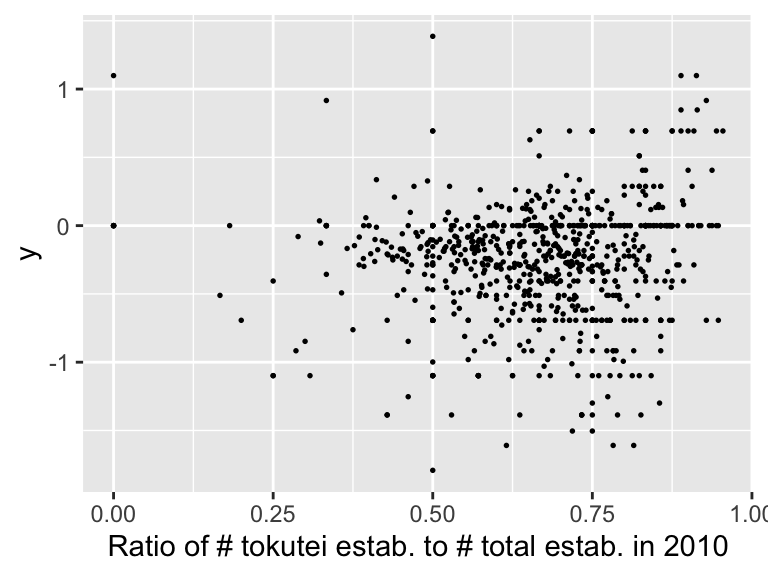

## binscatter plot for first stage

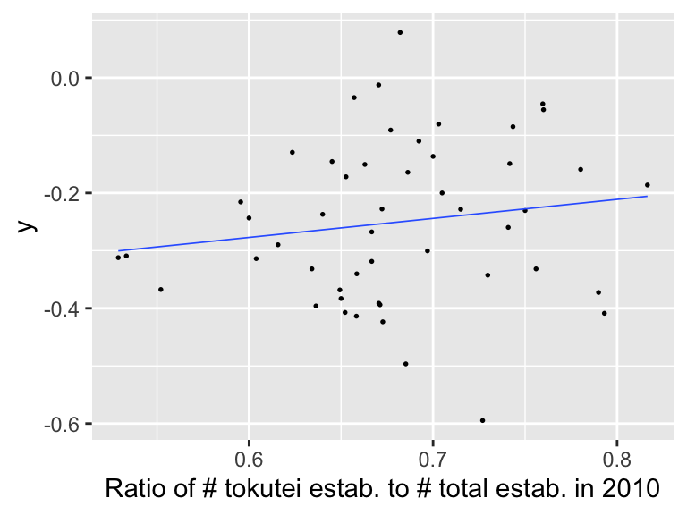

## Reduced form (zip)

Regress first order difference of the natural logarithm of the average wage and the average fee(log_diffwage_14_10 / flog_difffee_14_10) on the percentage of tokutei establishments at the initial period(share_zip_2010). The natural logarithm of the average wage and average fee are calculated by creating panel data by making the average of each zip code level year by year. log_diffwage_14_10 / flog_difffee_14_10 is log(average wage / fee in 2014) - log(average wage / fee in 2010).

### wage(log_diffwage_14_10)

|  | log_diffwage_14_10 |
| --- | --- |
| (Intercept) | −0.021 |
|  | [−0.085, 0.043] |
| share_zip_2010 | 0.045 |
|  | [−0.049, 0.139] |
| Num.Obs. | 778 |
| R2 | 0.001 |
| R2 Adj. | 0.000 |
| Log.Lik. | 147.279 |
| F | 0.889 |
| RMSE | 0.20 |

+ p < 0.1, * p < 0.05, ** p < 0.01, *** p < 0.001

### wage(wage_growth_14_10)

|  | wage_growth_14_10 |
| --- | --- |
| (Intercept) | −0.006 |
|  | [−0.103, 0.092] |
| share_zip_2010 | 0.058 |
|  | [−0.085, 0.201] |
| Num.Obs. | 778 |
| R2 | 0.001 |
| R2 Adj. | 0.000 |
| Log.Lik. | −183.131 |
| F | 0.637 |
| RMSE | 0.31 |

+ p < 0.1, * p < 0.05, ** p < 0.01, *** p < 0.001

### wage(weighted / log_diffwage_14_10)

|  | log_diffwage_14_10(weighted) |
| --- | --- |
| (Intercept) | 0.065* |
|  | [0.010, 0.119] |
| share_zip_2010 | −0.108* |
|  | [−0.197, −0.019] |
| Num.Obs. | 778 |
| R2 | 0.007 |
| R2 Adj. | 0.006 |
| Log.Lik. | 59.444 |
| F | 5.626 |
| RMSE | 0.20 |

+ p < 0.1, * p < 0.05, ** p < 0.01, *** p < 0.001

### wage(weighted / wage_growth_14_10)

|  | wage_growth_14_10(weighted) |
| --- | --- |
| (Intercept) | 0.056 |
|  | [−0.027, 0.138] |
| share_zip_2010 | −0.073 |
|  | [−0.208, 0.063] |
| Num.Obs. | 778 |
| R2 | 0.001 |
| R2 Adj. | 0.000 |
| Log.Lik. | −266.567 |
| F | 1.099 |
| RMSE | 0.31 |

+ p < 0.1, * p < 0.05, ** p < 0.01, *** p < 0.001

### Plot for reduced form (wage)

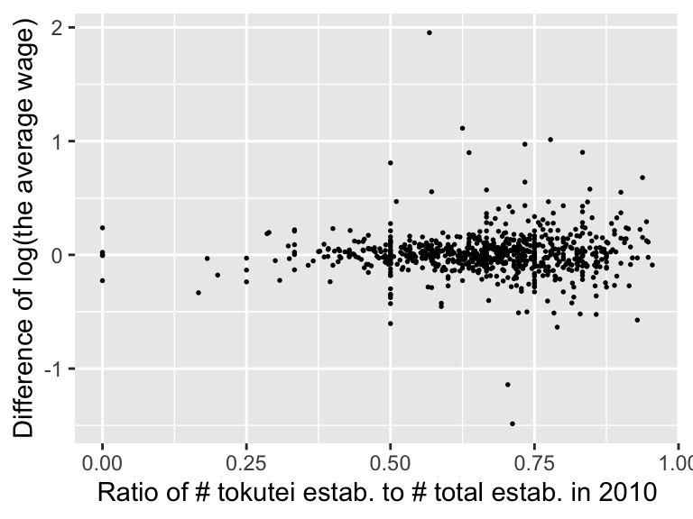

### binscatter plot for reduced form (wage)

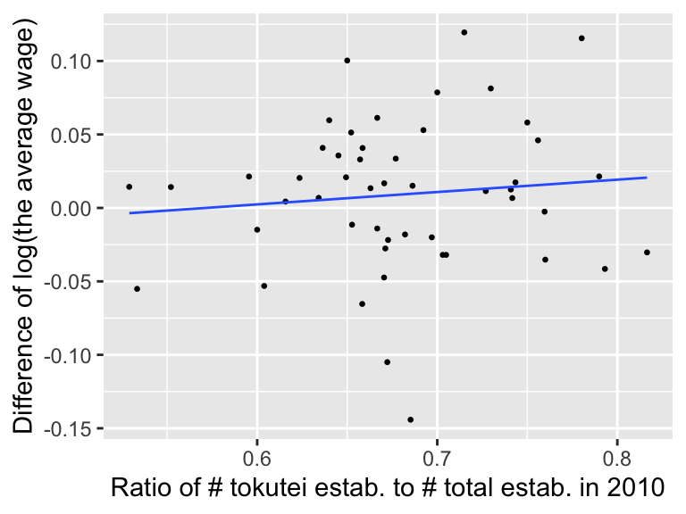

### fee(log_difffee_14_10)

|  | log_difffee_14_10 |
| --- | --- |
| (Intercept) | −0.046 |
|  | [−0.109, 0.017] |
| share_zip_2010 | 0.099* |
|  | [0.006, 0.192] |
| Num.Obs. | 778 |
| R2 | 0.006 |
| R2 Adj. | 0.004 |
| Log.Lik. | 153.314 |
| F | 4.380 |
| RMSE | 0.20 |

+ p < 0.1, * p < 0.05, ** p < 0.01, *** p < 0.001

### fee(fee_growth_14_10)

|  | fee_growth_14_10 |
| --- | --- |
| (Intercept) | −0.067+ |
|  | [−0.141, 0.008] |
| share_zip_2010 | 0.162** |
|  | [0.053, 0.271] |
| Num.Obs. | 778 |
| R2 | 0.011 |
| R2 Adj. | 0.010 |
| Log.Lik. | 30.037 |
| F | 8.534 |
| RMSE | 0.23 |

+ p < 0.1, * p < 0.05, ** p < 0.01, *** p < 0.001

### fee(log_difffee_14_10 / weighted )

|  | log_difffee_14_10(weighted) |
| --- | --- |
| (Intercept) | 0.052* |
|  | [0.001, 0.103] |
| share_zip_2010 | −0.067 |
|  | [−0.151, 0.017] |
| Num.Obs. | 778 |
| R2 | 0.003 |
| R2 Adj. | 0.002 |
| Log.Lik. | 107.953 |
| F | 2.439 |
| RMSE | 0.20 |

+ p < 0.1, * p < 0.05, ** p < 0.01, *** p < 0.001

### fee(fee_growth_14_10/ weighted )

|  | fee_growth_14_10(weighted) |
| --- | --- |
| (Intercept) | 0.033 |
|  | [−0.014, 0.080] |
| share_zip_2010 | −0.020 |
|  | [−0.097, 0.057] |
| Num.Obs. | 778 |
| R2 | 0.000 |
| R2 Adj. | −0.001 |
| Log.Lik. | 173.727 |
| F | 0.259 |
| RMSE | 0.24 |

+ p < 0.1, * p < 0.05, ** p < 0.01, *** p < 0.001

### Plot for reduced form (fee)

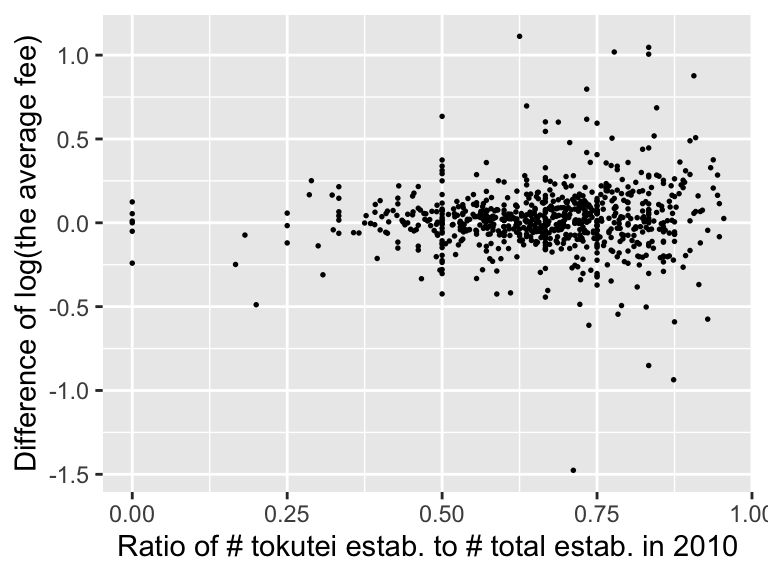

### binscatter plot for reduced form (fee)

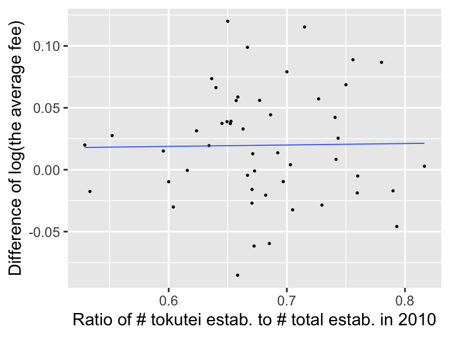

## Structural form (zip)

Regress the difference between the natural logarithm of average wages and average rates on the difference between 2014 and 2010 in the number of general establishments (log_diffwage/fee_14_10). We use the ratio of tokutei establishments at the initial periods as the instrument variable for the difference between the natural logarithm of average wages and average rates on the difference between 2014 and 2010 in the number of general establishments (log_diff_10_14).

### 2nd stage (wage / log_diffwage_14_10)

|  | log_diffwage_14_10 |
| --- | --- |
| (Intercept) | 0.054 |
|  | [−0.044, 0.153] |
| log_diff_10_14(fit) | 0.182 |
|  | [−0.209, 0.572] |
| Num.Obs. | 778 |
| R2 | −0.064 |
| R2 Adj. | −0.066 |
| RMSE | 0.21 |

+ p < 0.1, * p < 0.05, ** p < 0.01, *** p < 0.001

### 2nd stage (wage / wage_growth_14_10)

|  | wage_growth_14_10 |
| --- | --- |
| (Intercept) | 0.057+ |
|  | [−0.007, 0.121] |
| diff_14_10(fit) | 0.007 |
|  | [−0.011, 0.025] |
| Num.Obs. | 778 |
| R2 | −0.004 |
| R2 Adj. | −0.006 |
| RMSE | 0.31 |

+ p < 0.1, * p < 0.05, ** p < 0.01, *** p < 0.001

### 2nd stage (wage / log_diffwage_14_10 / weighted)

|  | log_diffwage_14_10(weighted) |
| --- | --- |
| (Intercept) | 0.073* |
|  | [0.005, 0.141] |
| fit_log_diff_10_14 | 0.353* |
|  | [0.027, 0.679] |
| Num.Obs. | 778 |
| R2 | −0.233 |
| R2 Adj. | −0.235 |
| RMSE | 0.24 |
| Std.Errors | IID |

+ p < 0.1, * p < 0.05, ** p < 0.01, *** p < 0.001

### 2nd stage (wage / wage_growth_14_10 / weighted)

|  | wage_growth_14_10(weighted) |
| --- | --- |
| (Intercept) | −0.044 |
|  | [−0.158, 0.070] |
| fit_diff_14_10 | −0.005 |
|  | [−0.015, 0.005] |
| Num.Obs. | 778 |
| R2 | −0.138 |
| R2 Adj. | −0.140 |
| RMSE | 0.32 |
| Std.Errors | IID |

+ p < 0.1, * p < 0.05, ** p < 0.01, *** p < 0.001

### 1st stage (wage / log_diffwage_14_10)

|  | log_diff_10_14(1st stage) |
| --- | --- |
| (Intercept) | −0.415*** |
|  | [−0.550, −0.280] |
| share_zip_2010 | 0.248* |
|  | [0.049, 0.446] |
| Num.Obs. | 778 |
| R2 | 0.008 |
| R2 Adj. | 0.006 |
| AIC | 879.9 |
| BIC | 893.9 |
| RMSE | 0.42 |

+ p < 0.1, * p < 0.05, ** p < 0.01, *** p < 0.001

### 1st stage (wage / wage_growth_14_10 )

|  | wage_growth_14_10(1st stage) |
| --- | --- |
| (Intercept) | −8.641*** |
|  | [−10.795, −6.486] |
| share_zip_2010 | 7.970*** |
|  | [4.809, 11.132] |
| Num.Obs. | 778 |
| R2 | 0.031 |
| R2 Adj. | 0.029 |
| AIC | 5187.5 |
| BIC | 5201.4 |
| RMSE | 6.76 |

+ p < 0.1, * p < 0.05, ** p < 0.01, *** p < 0.001

### 1st stage (wage / log_diff_10_14 / weighted )

|  | log_diff_10_14 |
| --- | --- |
| (Intercept) | −0.023 |
|  | [−0.118, 0.072] |
| share_zip_2010 | −0.306*** |
|  | [−0.462, −0.149] |
| Num.Obs. | 778 |
| R2 | 0.019 |
| R2 Adj. | 0.017 |
| AIC | 909.8 |
| BIC | 919.1 |
| RMSE | 0.43 |
| Std.Errors | IID |

+ p < 0.1, * p < 0.05, ** p < 0.01, *** p < 0.001

|  | diff_14_10 |
| --- | --- |
| (Intercept) | −20.523*** |
|  | [−26.239, −14.807] |
| share_zip_2010 | 14.938** |
|  | [5.539, 24.337] |
| Num.Obs. | 778 |
| R2 | 0.012 |
| R2 Adj. | 0.011 |
| AIC | 5789.8 |
| BIC | 5799.1 |
| RMSE | 9.97 |
| Std.Errors | IID |

+ p < 0.1, * p < 0.05, ** p < 0.01, *** p < 0.001

### 2nd stage (fee / log_difffee_14_10)

|  | log_difffee_14_10 |
| --- | --- |
| (Intercept) | 0.120* |
|  | [0.000, 0.239] |
| log_diff_10_14(fit) | 0.400+ |
|  | [−0.073, 0.873] |
| Num.Obs. | 778 |
| R2 | −0.583 |
| R2 Adj. | −0.585 |
| RMSE | 0.25 |

+ p < 0.1, * p < 0.05, ** p < 0.01, *** p < 0.001

### 2nd stage (fee / fee_growth_14_10)

|  | fee_growth_14_10 |
| --- | --- |
| (Intercept) | 0.109*** |
|  | [0.054, 0.164] |
| diff_14_10(fit) | 0.020* |
|  | [0.005, 0.036] |
| Num.Obs. | 778 |
| R2 | −0.283 |
| R2 Adj. | −0.285 |
| RMSE | 0.27 |

+ p < 0.1, * p < 0.05, ** p < 0.01, *** p < 0.001

### 2nd stage (fee / log_difffee_14_10 / weighted)

|  | log_difffee_14_10 |
| --- | --- |
| (Intercept) | 0.057+ |
|  | [−0.003, 0.118] |
| fit_log_diff_10_14 | 0.219 |
|  | [−0.072, 0.509] |
| Num.Obs. | 778 |
| R2 | −0.114 |
| R2 Adj. | −0.116 |
| RMSE | 0.21 |
| Std.Errors | IID |

+ p < 0.1, * p < 0.05, ** p < 0.01, *** p < 0.001

### 2nd stage (fee / fee_growth_14_10 / weighted)

|  | log_difffee_14_10 |
| --- | --- |
| (Intercept) | 0.006 |
|  | [−0.056, 0.067] |
| fit_diff_14_10 | −0.001 |
|  | [−0.007, 0.004] |
| Num.Obs. | 778 |
| R2 | −0.025 |
| R2 Adj. | −0.026 |
| RMSE | 0.24 |
| Std.Errors | IID |

+ p < 0.1, * p < 0.05, ** p < 0.01, *** p < 0.001

### 1st stage (fee / log_diff_10_14)

|  | log_diff_10_14(1st stage) |
| --- | --- |
| (Intercept) | −0.415*** |
|  | [−0.550, −0.280] |
| share_zip_2010 | 0.248* |
|  | [0.049, 0.446] |
| Num.Obs. | 778 |
| R2 | 0.008 |
| R2 Adj. | 0.006 |
| AIC | 879.9 |
| BIC | 893.9 |
| RMSE | 0.42 |

+ p < 0.1, * p < 0.05, ** p < 0.01, *** p < 0.001

### 1st stage (fee / fee_growth_14_10)

|  | fee_growth_14_10(1st stage) |
| --- | --- |
| (Intercept) | −8.641*** |
|  | [−10.795, −6.486] |
| share_zip_2010 | 7.970*** |
|  | [4.809, 11.132] |
| Num.Obs. | 778 |
| R2 | 0.031 |
| R2 Adj. | 0.029 |
| AIC | 5187.5 |
| BIC | 5201.4 |
| RMSE | 6.76 |

+ p < 0.1, * p < 0.05, ** p < 0.01, *** p < 0.001

### 1st stage (fee / log_difffee_14_10 / weighted)

|  | log_diff_10_14 |
| --- | --- |
| (Intercept) | −0.023 |
|  | [−0.118, 0.072] |
| share_zip_2010 | −0.306*** |
|  | [−0.462, −0.149] |
| Num.Obs. | 778 |
| R2 | 0.019 |
| R2 Adj. | 0.017 |
| AIC | 909.8 |
| BIC | 919.1 |
| RMSE | 0.43 |
| Std.Errors | IID |

+ p < 0.1, * p < 0.05, ** p < 0.01, *** p < 0.001

### 1st stage (fee / fee_growth_14_10 / weighted)

|  | diff_14_10 |
| --- | --- |
| (Intercept) | −20.523*** |
|  | [−26.239, −14.807] |
| share_zip_2010 | 14.938** |
|  | [5.539, 24.337] |
| Num.Obs. | 778 |
| R2 | 0.012 |
| R2 Adj. | 0.011 |
| AIC | 5789.8 |
| BIC | 5799.1 |
| RMSE | 9.97 |
| Std.Errors | IID |

+ p < 0.1, * p < 0.05, ** p < 0.01, *** p < 0.001